# RR2 draft

Author

Ouissal Akioui

# Introduction

This report examines the thematic structure of cultural coverage in Moroccan digital news. The dataset consists of 15,966 articles drawn from four major online outlets — Hespress, Hibapress, Le360, and Akhbarona — filtered to the Culture category from a larger Arabic-language news corpus. Each observation corresponds to a single published article, with outlet identity recorded as the primary grouping variable.

Rather than treating cultural news as a homogeneous category, this analysis asks how cultural coverage is internally structured and whether outlets differ in their thematic priorities. I use a Structural Topic Model (STM) to identify 10 latent sub-themes within the corpus, ranging from cinema and music festivals to literary culture and institutional policy coverage. Topic proportions are then regressed on outlet identity to test the following hypotheses.

H1: Thematic emphasis in cultural news coverage differs significantly across Moroccan digital outlets.

H2: Le360 and Hespress will allocate greater coverage to institutional and literary cultural topics compared to Hibapress and Akhbarona, with Le360 leading in literary and intellectual themes given its formally oriented reputation, and Hespress following closely behind due to its perceived institutional character.

# PART 1: PREPARATION

## SECTION 1 : COMBINING DATASETS

Four filtered datasets were merged into a single dataframe containing 15,966 articles and three variables: article title, body text, and source.

```r
rm(list=ls()) #This line of code cleans the environment
```

```r
library(tidyverse)

# Load all datasets with source labels
hespress   <- read_csv("Hespress.ma.csv",   show_col_types = FALSE) %>% mutate(source = "Hespress")
hibapress  <- read_csv("Hibapress.com.csv", show_col_types = FALSE) %>% mutate(source = "Hibapress")
le360      <- read_csv("Le360.com.csv",     show_col_types = FALSE) %>% mutate(source = "Le360")
akhbarona  <- read_csv("Akhbarona.ma.csv",  show_col_types = FALSE) %>% mutate(source = "Akhbarona")
```

```r
#filtering all of them to keep only culture
hespress_c  <- hespress  %>% filter(Category == "Culture")
hibapress_c <- hibapress %>% filter(Category == "Culture")
le360_c     <- le360     %>% filter(Category == "Culture")
akhbarona_c <- akhbarona %>% filter(Category == "Culture")
```

```r
#merging all of it in one with a newly created source variable
culture_df <- bind_rows(hespress_c, hibapress_c, le360_c, akhbarona_c)

table(culture_df$source)
```

```
Akhbarona  Hespress Hibapress     Le360
     2008      7809      2481      3668
```

```r
nrow(culture_df)
```

```
[1] 15966
```

```r
#remove category since there is just one
culture_df <- culture_df %>% select(-Category)
View(culture_df)
```

## SECTION 2 : TEXT PREPROCESSING FOR ARABIC TOPIC MODELLING

Before the topic model could be run, the raw article text required several cleaning steps to reduce noise and isolate meaningful content.

The first step was basic text normalization. URLs, email addresses, numbers, and punctuation were stripped from the text. Arabic diacritics (tashkeel, the small vowel marks written above and below letters) were also removed, as the same word can appear with or without them across articles and they would otherwise be treated as distinct tokens.

The text was then tokenized, split into individual words, producing one token per row, which is the format the topic model requires.

The most iterative part of preprocessing was stopword removal. Arabic presents a particular challenge here: the language has an enormous number of functional words, particles, and conjunctions that carry no thematic meaning, and standard stopword lists do not catch all of them. A base list from the `stopwords` package (stopwords-iso) was used as a starting point, but it required substantial manual extension. Words like “said”, “this”, “after”, and common reporting verbs were added by hand after inspecting which high-frequency words were slipping through. The word “Morocco” (المغرب) was also removed, since every article in the corpus is about Morocco by definition, it appears so frequently that it would dominate topics without adding any discriminating information.

One decision worth noting: the text was **not stemmed**. In many languages, stemming (reducing words to their root form) is a useful normalization step. Arabic, however, is a root-and-pattern language where words are built from three-letter roots through internal vowel changes and affixes, not simple prefix or suffix removal. Standard stemming approaches designed for languages like English perform poorly on Arabic and can distort meaning. Keeping the full word forms was therefore a more conservative and reliable choice, at the cost of some vocabulary redundancy.

```r
library(tidyverse)
library(tidytext)
library(stopwords)
library(stringr)


# 1A: CLEAN THE RAW TEXT

culture_clean <- culture_df %>%
  mutate(
    text = Body,

    # Remove URLs
    text = str_remove_all(text, "https?://\\S+|www\\.\\S+"),

    # Remove email addresses
    text = str_remove_all(text, "\\S+@\\S+"),

    # Remove numbers
    text = str_remove_all(text, "[[:digit:]]"),

    # removes dots and punctuation more aggressively
    text = str_remove_all(text, "[[:punct:]٪،؛؟!«»\\.\\-]"),

    # Remove Arabic diacritics (tashkeel - the small vowel marks)
    text = str_remove_all(text, "[\u064B-\u065F]"),

  ) %>%
  # Add a unique document ID — we'll need this later
  mutate(doc_id = row_number())



# 1B: TOKENIZE (one word per row)

culture_tokens <- culture_clean %>%
  select(doc_id, source, text) %>%
  unnest_tokens(
    output = word,   # new column name for each token
    input  = text,   # column to tokenize
    token  = "words" # split by words
  )

# How many tokens total?
nrow(culture_tokens)
```

```
[1] 4410412
```

```r
# 1C: REMOVE STOPWORDS


# Get Arabic stopwords from the stopwords package
arabic_stopwords <- stopwords("ar", source = "stopwords-iso")

# Also add some common noise words manually
# (we expand this list as we see what slips through)

custom_stopwords <- c(
  "قال", "قالت", "أن", "التي", "الذي", "وقد", "كان", "كانت",
  "هذا", "هذه", "وهو", "وهي", "أو", "لا", "ما", "مع", "عن",
  "في", "من", "على", "إلى", "عند", "حيث", "بعد", "قبل",
  "هناك", "يوم", "خلال", "حول", "بين", "أكد", "أضاف",
  "انه","أنه", "مغرب", "عبر", "عبد"  # morocco "مغرب" is  is so frequent it's basically noise.
)

custom_stopwords2 <- c(
  "وذلك", "أيضا", "إلا", "لأن", "أخرى", "خاصة",
  "المغربية", "المغربي", "المغرب", "مغربي", "مغربية",
  "مغاربة", "المغاربة", "مغربيين", "مغربيات",
  "مغاربي", "مغاربية", "بالمغرب", "للمغرب",
  "المغرب"
)

all_stopwords <- c(arabic_stopwords, custom_stopwords, custom_stopwords2)

# Filter them out
culture_tokens <- culture_tokens %>%
  filter(!word %in% all_stopwords)

# Remove only the definite article ال from the beginning of each token
# No other stemming applied
culture_tokens <- culture_tokens %>%
  mutate(word = str_remove(word, "^ال"))


# 1D: REMOVE SHORT TOKENS (less than 2 characters)
# These are usually noise — conjunctions, leftover particles

culture_tokens <- culture_tokens %>%
  filter(nchar(word) >= 2)


culture_tokens %>%
  count(word, sort = TRUE) %>%
  head(30)
```

```
# A tibble: 30 × 2
   word       n
   <chr>  <int>
 1 فيلم   11618
 2 مهرجان 10786
 3 محمد   10223
 4 فنان    9563
 5 فنية    8156
 6 أغنية   6902
 7 ثقافة   6786
 8 عالم    6582
 9 عربية   6276
10 عمل     6163
# ℹ 20 more rows
```

Before running the topic model, we save a small reference table that links each article to its outlet. This is needed later to tell the model which newspaper published each piece.

```r
#SAVE THE METADATA (we'll need source labels later for STM)

culture_meta <- culture_clean %>%
  select(doc_id, source)
```

# PART 2: STM & REGRESSION

## SECTION 1: THE STRUCTURAL TOPIC MODEL

A Structural Topic Model (STM) is a method that automatically discovers recurring themes in a large collection of texts. The basic idea is simple: words that tend to appear together probably belong to the same theme. Feed the model 15,966 articles and it will find, on its own, that “film”, “director”, and “screening” keep showing up in the same articles, and label that cluster a topic. You then inspect the top words and give the topic a human-readable name.

What makes STM different from simpler versions of this approach is that it lets you bring in extra information about each document, in this case, which outlet published it. This means the model can go beyond just finding themes and actually test whether outlet identity predicts how much of each theme an article contains. That’s the bridge between the topic modeling and the hypothesis.

Before the topic model can run, the cleaned text needs to be converted into a numerical format the algorithm can process. This takes the form of a Document-Feature Matrix (DFM); a large table where each row represents one article, each column represents a word from the full vocabulary, and each cell records how many times that word appeared in that article. Most cells are zero, since any given article only uses a small fraction of the total vocabulary. This matrix is built directly from the cleaned tokens and then converted into the format the STM package expects.

```r
library(quanteda)

# Build dfm directly from tokens
culture_dfm <- culture_tokens %>%
  count(doc_id, word) %>%
  cast_dfm(document = doc_id, term = word, value = n)

# Now convert to STM format — this will work
culture_stm <- convert(culture_dfm, to = "stm")

# Align metadata
meta_aligned <- culture_meta %>%
  filter(doc_id %in% as.integer(culture_stm$documents %>% names())) %>%
  arrange(doc_id)
```

The model is set to find 10 topics. An earlier exploratory run with 15 produced too much overlap between adjacent themes, cinema and film festivals kept bleeding into each other, for instance, so 10 is a cleaner, more interpretable solution. We can see a snippet of it below in the first topic proportions summary plot (Figure 1).

```r
library(stm)

# RUN K=15 (just for comparison figure)
if (!file.exists("stm_model_k15.rds")) {
  stm_model_k15 <- stm(
    documents  = culture_stm$documents,
    vocab      = culture_stm$vocab,
    K          = 15,
    prevalence = ~ source,
    data       = meta_aligned,
    max.em.its = 75,
    init.type  = "Spectral",
    verbose    = TRUE
  )
  saveRDS(stm_model_k15, "stm_model_k15.rds")
} else {
  stm_model_k15 <- readRDS("stm_model_k15.rds")
}
```

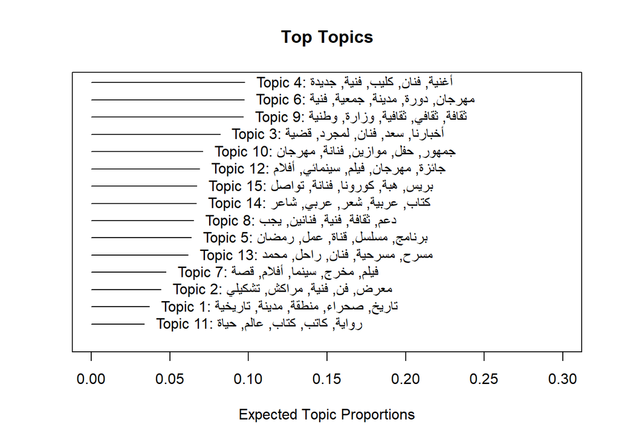

```r
# Topic proportions summary plot
plot(stm_model_k15, type = "summary", xlim = c(0, 0.3), n = 5)
```

**Figure 1:** *Expected proportion of each topic across the 15,966-article corpus with k=15. Topics are ordered by prevalence. Labels reflect the five highest-probability words per topic.*

The 15-topic solution suffers from weak discriminant validity between topics. Instead of yielding clearly distinct thematic clusters, it fragments coherent domains into multiple, partially redundant topics. This is particularly evident in the overlap between cinema-related themes (e.g., films, festivals, actors), which appear split across several topics with highly similar vocabularies. This “topic bleeding” indicates that the model is overfitting the latent structure—capturing noise and micro-variations rather than substantively meaningful distinctions. As a result, interpretability declines: topics become harder to label, less theoretically coherent, and less useful for downstream analysis. In contrast, a more parsimonious solution (e.g., k=10) better aggregates related terms into unified themes, improving both clarity and analytical leverage.

```r
library(stm)

# Run STM
if (!file.exists("stm_model_k10.rds")) {
  stm_model_k10 <- stm(
    documents  = culture_stm$documents,
    vocab      = culture_stm$vocab,
    K          = 10,
    prevalence = ~ source,
    data       = meta_aligned,
    max.em.its = 75,
    init.type  = "Spectral",
    verbose    = TRUE
  )
  saveRDS(stm_model_k10, "stm_model_k10.rds")
} else {
  stm_model_k10 <- readRDS("stm_model_k10.rds")
}

# Make sure stm_model still points to k10 for rest of analysis
stm_model <- stm_model_k10
```

Once the model converged, topic interpretation proceeded through close inspection of the top words associated with each topic across four metrics: highest probability words, FREX words (which are frequent within the topic but rare across others), and score-weighted terms. Labels were assigned on the basis of semantic coherence across these lists, with FREX words carrying particular weight since they capture what is genuinely distinctive about a topic rather than what is merely common.

```r
# Top words per topic
labelTopics(stm_model, n = 10)
```

```r
## Assign labels based on inspection
topic_labels <- c(
  "Books, Poetry & Literary Culture",     # Topic 1 — كتاب، رواية، شعر، شاعر، أدب
  "Visual Arts & Heritage",               # Topic 2 — معرض، متحف، تشكيلي، لوحات
  "Celebrity Scandals & Legal",           # Topic 3 — لمجرد، اغتصاب، قضائية، محكمة
  "Music & Songs",                        # Topic 4 — أغنية، كليب، ألبوم، راب
  "TV & Ramadan Series",                  # Topic 5 — مسلسل، رمضان، قناة، مسرحية
  "Cultural Festivals & Events",          # Topic 6 — مهرجان، دورة، فعاليات، كناوة
  "Cinema & Film Awards",                 # Topic 7 — فيلم، سينما، أوسكار، مخرج
  "Opinion & Cultural Criticism",         # Topic 8 — يجب، مجتمع، يقول، فن
  "Cultural Policy & Ministry",           # Topic 9 — وزارة، ثقافة، دعم، اتفاقية
  "Celebrity Social Media"                # Topic 10 — انستقرام، فنانة، نجمة، إليسا
)
```

To illustrate the process concretely, consider Topic 7. Its highest probability words include فيلم (film), سينما (cinema), أفلام (films), مخرج (director), and جائزة (prize). Its FREX words include أوسكار (Oscars), سعفة (Palme d’Or), and سكورسيزي (Scorsese). Taken together, these terms point unambiguously to coverage of cinema as an art form — festival awards, critical reception, and auteur directors. The label ‘Cinema & Film Awards’ follows directly from this pattern.

This labeling process is inherently qualitative and involves interpretive judgment. A different analyst might draw slightly different boundaries, particularly for topics with overlapping vocabularies.

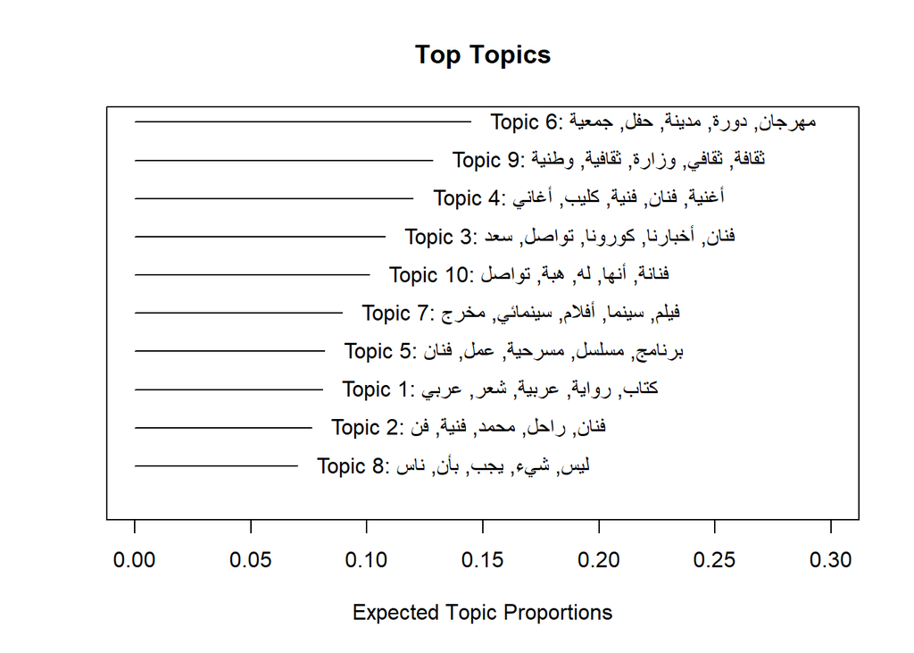

```r
# Topic proportions summary plot
plot(stm_model, type = "summary", xlim = c(0, 0.3), n=5)
```

**Figure 2**. Expected proportion of each topic across the 15,966-article corpus with k=10. Topics are ordered by prevalence. Labels reflect the five highest-probability words per topic.

Taken together, this distribution suggests that Moroccan digital cultural news is structured primarily around events, institutions, and music, with celebrity content present but not dominant at the corpus level, a pattern that may however vary considerably across outlets.

Having confirmed that the topic model converged, the estimated topic proportions are extracted from the model object. Each article is represented as a vector of 10 values summing to one (10 topics), where each value reflects the share of that article’s content attributed to a given topic. Outlet identity is then re-attached to this dataframe, producing the dataset used for all subsequent outlet-level comparisons.

```r
# Extract topic proportions per document
topic_proportions <- as.data.frame(stm_model$theta)

# theta is the matrix where each row is an article
# and each column is a topic — values are the proportions
colnames(topic_proportions) <- topic_labels

# Add source back
topic_proportions$source <- meta_aligned$source

# Peek at it
head(topic_proportions)
```

## SECTION 2: ESTIMATE EFFECT OF SOURCE ON TOPIC PREVALENCE

Before estimating outlet-specific effects, I first conduct one-way ANOVA tests on document-level topic proportions to assess whether topic prevalence differs across news outlets at all. For each of the 10 topics, this provides a global test of whether mean topic proportions vary significantly by source. This step serves as a preliminary diagnostic: rather than identifying which outlets differ from a reference category, it establishes whether outlet-level variation exists in the first place. I then use `estimateEffect` to model those differences more precisely within the STM framework, allowing outlet comparisons while incorporating uncertainty from the topic model itself.

```r
library(dplyr)
library(knitr)
library(kableExtra)

# make sure source is a factor
meta_aligned$source <- as.factor(meta_aligned$source)

# extract topic proportions
theta <- stm_model$theta

# run one-way ANOVA for all topics
anova_results <- lapply(1:ncol(theta), function(k) {
  model <- lm(theta[, k] ~ source, data = meta_aligned)
  aov_tab <- anova(model)

  data.frame(
    topic = paste0("Topic ", k),
    df_between = aov_tab$Df[1],
    df_within = aov_tab$Df[2],
    F_value = aov_tab$`F value`[1],
    p_value = aov_tab$`Pr(>F)`[1]
  )
})

anova_results <- do.call(rbind, anova_results)


anova_results %>%
  mutate(p_value_display = format(p_value, scientific = TRUE)) %>%
  select(topic, df_between, df_within, F_value, p_value_display) %>%
  rename(
    Topic = topic,
    `df between` = df_between,
    `df within` = df_within,
    `F statistic` = F_value,
    `p-value` = p_value_display
  ) %>%
  # kable() tends to round very small numeric p-values to 0, which is misleading.
# To avoid this, p-values are converted to a character format using scientific notation.
  kable(
    caption = "One-way ANOVA results for topic prevalence by news outlet",
    align = "c"
  ) %>%
  kable_styling(
    full_width = FALSE,
    bootstrap_options = c("striped", "hover"),
    position = "center"
  )
```

One-way ANOVA results for topic prevalence by news outlet

| Topic | df between | df within | F statistic | p-value |
| --- | --- | --- | --- | --- |
| Topic 1 | 3 | 15961 | 535.49635 | 0.000000e+00 |
| Topic 2 | 3 | 15961 | 41.25304 | 1.512667e-26 |
| Topic 3 | 3 | 15961 | 1097.00497 | 0.000000e+00 |
| Topic 4 | 3 | 15961 | 118.70026 | 4.987138e-76 |
| Topic 5 | 3 | 15961 | 128.21898 | 4.506794e-82 |
| Topic 6 | 3 | 15961 | 305.32845 | 9.239187e-193 |
| Topic 7 | 3 | 15961 | 54.62626 | 4.029477e-35 |
| Topic 8 | 3 | 15961 | 422.69232 | 2.947188e-264 |
| Topic 9 | 3 | 15961 | 158.01987 | 6.206018e-101 |
| Topic 10 | 3 | 15961 | 900.15946 | 0.000000e+00 |

**Table 1:** One-way ANOVA results for topic prevalence by news outlet. Each test evaluates whether mean topic proportions differ across sources

The ANOVA results reveal substantial between-outlet variation in topic prevalence across all 10 topics. For each topic, the null hypothesis of equal mean proportions across sources is decisively rejected (all p < .001), indicating that topic distributions are strongly structured by outlet identity. The magnitude of the F-statistics further suggests that these differences are not trivial but reflect meaningful divergence in editorial focus across news sources.

To examine whether thematic emphasis in cultural coverage varies across news outlets, I use the `estimateEffect` function from the STM package, which regresses estimated topic proportions on outlet identity. For each of the 10 topics, the model estimates how much each outlet deviates from the baseline in its coverage of that topic. Unlike a standard OLS regression applied to raw topic proportions, `estimateEffect` incorporates the posterior uncertainty from the topic model itself when computing standard errors, producing more honest estimates. The `uncertainty = "Global"` option propagates this uncertainty globally across the model. Source (news outlet) is the sole predictor, with Akhbarona serving as the reference category by default due to alphabetical ordering. This baseline choice is arbitrary and does not affect the substantive interpretation of results, as the analysis focuses on relative differences between outlets rather than on the specific reference category.

```r
effect <- estimateEffect(
  formula     = 1:10 ~ source,
  stmobj      = stm_model,
  metadata    = meta_aligned,
  uncertainty = "Global"
)

summary(effect, topics = 1:10)
```

```r
library(knitr)
library(kableExtra)

# Extract coefficients into a clean dataframe
reg_table <- data.frame()

for (t in 1:10) {
  coefs <- summary(effect, topics = t)$tables[[1]]
  rows <- coefs[c("sourceHespress", "sourceHibapress", "sourceLe360"), ]

  reg_table <- rbind(reg_table, data.frame(
    Topic    = topic_labels[t],
    Outlet   = gsub("source", "", rownames(rows)),
    Estimate = round(rows[, "Estimate"], 3),
    SE       = round(rows[, "Std. Error"], 3),
    p        = round(rows[, "Pr(>|t|)"], 3)
  ))
}

# Add significance stars
reg_table$p <- ifelse(reg_table$p < 0.001, "<.001 ***",
               ifelse(reg_table$p < 0.01,  "<.01 **",
               ifelse(reg_table$p < 0.05,  "<.05 *",
               as.character(reg_table$p))))

kable(reg_table, row.names = FALSE,
      col.names = c("Topic", "Outlet", "β", "SE", "p")) %>%
  kable_styling(full_width = FALSE, font_size = 12) %>%
  collapse_rows(columns = 1, valign = "top")
```

| Topic | Outlet | β | SE | p |
| --- | --- | --- | --- | --- |
| Books, Poetry & Literary Culture | Hespress | 0.111 | 0.006 | <.001 *** |
|  | Hibapress | -0.016 | 0.006 | <.05 * |
|  | Le360 | 0.010 | 0.006 | 0.106 |
| Visual Arts & Heritage | Hespress | 0.038 | 0.005 | <.001 *** |
|  | Hibapress | 0.008 | 0.006 | 0.227 |
|  | Le360 | 0.034 | 0.006 | <.001 *** |
| Celebrity Scandals & Legal | Hespress | -0.227 | 0.007 | <.001 *** |
|  | Hibapress | -0.107 | 0.008 | <.001 *** |
|  | Le360 | -0.224 | 0.007 | <.001 *** |
| Music & Songs | Hespress | 0.041 | 0.007 | <.001 *** |
|  | Hibapress | 0.076 | 0.008 | <.001 *** |
|  | Le360 | 0.106 | 0.008 | <.001 *** |
| TV & Ramadan Series | Hespress | -0.064 | 0.006 | <.001 *** |
|  | Hibapress | -0.028 | 0.008 | <.001 *** |
|  | Le360 | -0.084 | 0.007 | <.001 *** |
| Cultural Festivals & Events | Hespress | 0.043 | 0.007 | <.001 *** |
|  | Hibapress | 0.009 | 0.008 | 0.265 |
|  | Le360 | 0.148 | 0.007 | <.001 *** |
| Cinema & Film Awards | Hespress | 0.031 | 0.006 | <.001 *** |
|  | Hibapress | -0.017 | 0.007 | <.05 * |
|  | Le360 | 0.025 | 0.007 | <.001 *** |
| Opinion & Cultural Criticism | Hespress | 0.053 | 0.005 | <.001 *** |
|  | Hibapress | -0.018 | 0.006 | <.01 ** |
|  | Le360 | -0.038 | 0.005 | <.001 *** |
| Cultural Policy & Ministry | Hespress | 0.060 | 0.006 | <.001 *** |
|  | Hibapress | -0.035 | 0.008 | <.001 *** |
|  | Le360 | 0.066 | 0.008 | <.001 *** |
| Celebrity Social Media | Hespress | -0.085 | 0.006 | <.001 *** |
|  | Hibapress | 0.128 | 0.008 | <.001 *** |
|  | Le360 | -0.043 | 0.006 | <.001 *** |

**Table 2.** presents the estimated coefficients, standard errors, and significance levels for all ten topics across the three remaining outlets.

The regression results reveal substantial and statistically significant differences in thematic emphasis across all four outlets, with Akhbarona serving as the reference category. These results support H1: outlet identity is a meaningful predictor of cultural topic prevalence.

Turning to H2, the findings only partially confirm the hypothesis. As expected, Hespress does not behave like a typical mass-audience outlet. It allocates significantly more coverage to Books, Poetry & Literary Culture (β = 0.110, p < .001), Opinion & Cultural Criticism (β = 0.053, p < .001), and Cultural Policy & Ministry (β = 0.060, p < .001) than Akhbarona — and crucially, more than Le360 on the literary and intellectual dimensions. Le360, which was expected to lead on serious cultural content, instead shows its strongest advantage on Cultural Festivals & Events (β = 0.148, p < .001), Music & Songs (β = 0.105, p < .001), and Cultural Policy & Ministry (β = 0.066, p < .001) — a more event-driven, institutionalized profile rather than a literary one.

The pattern that emerges is therefore more nuanced than a simple serious-versus-popular divide. Hespress occupies an unexpected literary and critical niche, Le360 owns the institutional and event-driven cultural space, and Hibapress corners celebrity and entertainment content.

## SECTION 3: BOOTSTRAPPING

Specification curve analysis using the specr package is not directly applicable to the STM framework used in Part 2 of this analysis. The estimateEffect function operates on posterior distributions from the topic model rather than a standard regression object, and cannot be passed to specr’s setup() function which expects a conventional lm or glm model. The robustness of the STM results is instead assessed through the bootstrap procedure reported in this Section.

What we’re doing is bootstrapping the regression step conditional on the topic model being fixed, instead of a bootstrap re-estimating the entire topic model on each bootstrap sample.

The regression estimates above rely on standard errors that incorporate posterior uncertainty from the topic model itself, but a further robustness check is warranted. To confirm that the outlet differences identified are stable and not an artifact of the specific sample, I complement the regression with a bootstrap procedure. Rather than re-estimating the full topic model on each iteration (which would be computationally a lot), the bootstrap resamples articles with replacement and refits the regression on each sample, holding the topic model fixed. This produces empirical confidence intervals that do not depend on distributional assumptions. If the bootstrapped intervals align with the regression results and do not straddle zero for the same coefficients, the findings can be considered robust.

```r
#| results: hide
#| message: false

set.seed(123)
n_boot <- 1000  # number of bootstrap iterations

# Store bootstrapped coefficients for each topic
boot_results <- list()

for (t in 1:10) {
  topic_prop <- stm_model$theta[, t]  # Extract topic proportion for this topic
  boot_data <- data.frame(        # Combine with source
    proportion = topic_prop,
    source     = meta_aligned$source
  )

  # Bootstrap
  boot_coefs <- replicate(n_boot, {
    idx    <- sample(nrow(boot_data), replace = TRUE) # Resample with replacement
    sample <- boot_data[idx, ]
    fit    <- lm(proportion ~ source, data = sample)  # Refit regression
    coef(fit)
  })
  boot_results[[t]] <- t(boot_coefs)
}

# Build summary table
boot_summary <- data.frame()

for (t in 1:10) {
  ci <- apply(boot_results[[t]], 2, quantile, probs = c(0.025, 0.975))
  for (src in c("sourceHespress", "sourceHibapress", "sourceLe360")) {
    boot_summary <- rbind(boot_summary, data.frame(
      Topic  = topic_labels[t],
      Outlet = gsub("source", "", src),
      Lower  = round(ci[1, src], 3),
      Upper  = round(ci[2, src], 3)
    ))
  }
}
```

Table 3. Bootstrapped 95% Confidence Intervals (ref: Akhbarona)

| Topic | Outlet | 2.5% | 97.5% |
| --- | --- | --- | --- |
| Books, Poetry & Literary Culture | Hespress | 0.108 | 0.122 |
|  | Hibapress | -0.019 | -0.010 |
|  | Le360 | 0.003 | 0.014 |
| Visual Arts & Heritage | Hespress | 0.034 | 0.049 |
|  | Hibapress | 0.000 | 0.017 |
|  | Le360 | 0.029 | 0.047 |
| Celebrity Scandals & Legal | Hespress | -0.268 | -0.239 |
|  | Hibapress | -0.141 | -0.108 |
|  | Le360 | -0.270 | -0.241 |
| Music & Songs | Hespress | 0.039 | 0.057 |
|  | Hibapress | 0.069 | 0.094 |
|  | Le360 | 0.105 | 0.128 |
| TV & Ramadan Series | Hespress | -0.077 | -0.055 |
|  | Hibapress | -0.044 | -0.018 |
|  | Le360 | -0.101 | -0.078 |
| Cultural Festivals & Events | Hespress | 0.040 | 0.058 |
|  | Hibapress | 0.000 | 0.022 |
|  | Le360 | 0.149 | 0.176 |
| Cinema & Film Awards | Hespress | 0.028 | 0.046 |
|  | Hibapress | -0.028 | -0.009 |
|  | Le360 | 0.019 | 0.040 |
| Opinion & Cultural Criticism | Hespress | 0.046 | 0.060 |
|  | Hibapress | -0.024 | -0.011 |
|  | Le360 | -0.040 | -0.028 |
| Cultural Policy & Ministry | Hespress | 0.055 | 0.076 |
|  | Hibapress | -0.047 | -0.027 |
|  | Le360 | 0.059 | 0.083 |
| Celebrity Social Media | Hespress | -0.098 | -0.078 |
|  | Hibapress | 0.127 | 0.158 |
|  | Le360 | -0.057 | -0.034 |

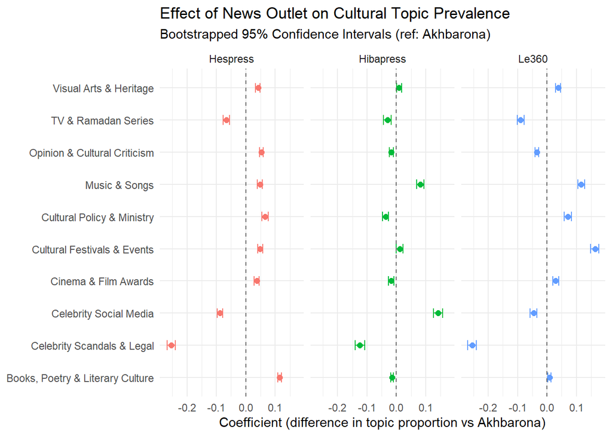

```r
library(ggplot2)

# Build a dataframe of bootstrapped CIs
plot_data <- data.frame()

for (t in 1:10) {
  ci <- apply(boot_results[[t]], 2, quantile, probs = c(0.025, 0.5, 0.975))

  for (src in c("sourceHespress", "sourceHibapress", "sourceLe360")) {
    plot_data <- rbind(plot_data, data.frame(
      topic  = topic_labels[t],
      source = gsub("source", "", src),
      lo     = ci[1, src],
      mid    = ci[2, src],
      hi     = ci[3, src]
    ))
  }
}

# Plot
ggplot(plot_data, aes(x = mid, y = topic, color = source)) +
  geom_point(position = position_dodge(0.5), size = 2) +
  geom_errorbarh(aes(xmin = lo, xmax = hi),
                 position = position_dodge(0.5), height = 0.3) +
  geom_vline(xintercept = 0, linetype = "dashed", color = "gray40") +
  facet_wrap(~ source) +
  labs(
    title = "Effect of News Outlet on Cultural Topic Prevalence",
    subtitle = "Bootstrapped 95% Confidence Intervals (ref: Akhbarona)",
    x = "Coefficient (difference in topic proportion vs Akhbarona)",
    y = NULL
  ) +
  theme_minimal() +
  theme(legend.position = "none")
```

**Figure 3.** Effect of news outlet on cultural topic prevalence, relative to Akhbarona (reference category). Points represent bootstrapped median coefficients and horizontal lines denote 95% confidence intervals. Coefficients to the right of zero indicate greater topic prevalence relative to Akhbarona; coefficients to the left indicate lower prevalence.

These results broadly support H1: outlet identity does predict thematic emphasis, and the differences are statistically robust across nearly all topics.

The most direct test of H2 is visible in the Books, Poetry & Literary Culture and Opinion & Cultural Criticism rows: Hespress sits clearly to the right while Le360 remains comparatively closer to zero or weaker on the critical dimension, confirming that Hespress, not Le360, is the literary outlet in the Moroccan cultural news landscape according to this corpus. This is the core finding of the analysis.

# PART 3: PREDICTIVE MODELLING

**Research Question:** What article-level features predict the degree of celebrity focus in Moroccan cultural news articles?

Having established that outlet identity shapes thematic emphasis in Moroccan cultural news, I now extend the analysis into a predictive framework. The outcome variable is a composite celebrity focus score, constructed by summing each article’s STM-estimated proportions on the *Celebrity Scandals & Legal* *(Topic 3)* and *Celebrity Social Media (Topic 10)* topics. These two topics are combined because they both capture distinct but complementary forms of celebrity-oriented coverage, and treating them separately would artificially fragment a single underlying dimension of celebrity focus.

Predictors include outlet identity, article length, title length, vocabulary richness, and the proportion of foreign-script characters (entre autres) in the body text. I first evaluate a baseline linear regression on a held-out test set, then use 10-fold cross-validation to obtain a more reliable estimate of predictive performance, and finally apply lasso regression to determine which subset of features produces the most predictive model.

## SECTION 1: BUILDING OUR PREDICTORS AND OUTCOME

### COMPUTING VARIABLES

**Article length**

```r
culture_df <- culture_df %>%
  mutate(article_length = str_count(Body, "\\S+"))
```

**Title length**

```r
culture_df <- culture_df %>%
  mutate(title_length = str_count(Title, "\\S+"))
```

**Vocabulary richness**

```r
culture_df <- culture_df %>% mutate(doc_id = row_number())
vocab_richness <- culture_tokens %>%
  group_by(doc_id) %>%
  summarise(
    total_words  = n(),
    unique_words = n_distinct(word),
    vocab_rich   = unique_words / total_words
  )
culture_df <- culture_df %>% left_join(vocab_richness, by = "doc_id")
```

**Proportion of foreign words**

```r
culture_df <- culture_df %>%
  mutate(
    latin_chars = str_count(Body, "[A-Za-z]"),
    total_chars = nchar(Body),
    foreign_prop = latin_chars / total_chars
  )
```

**Topic proportions**

```r
topic_props <- as.data.frame(stm_model$theta)
colnames(topic_props) <- paste0("topic_", 1:10)

meta_aligned <- bind_cols(meta_aligned, topic_props)

culture_df <- culture_df %>%
  left_join(
    meta_aligned %>% select(doc_id, starts_with("topic_")),
    by = "doc_id"
  )
```

**Celebrity score: the outcome**

[figure not shown]

```r
# Add celebrity_score as a new column in culture_df
culture_df <- culture_df %>%
  mutate(celebrity_score = topic_10 + topic_3)

# Histogram of celebrity score distribution
ggplot(culture_df %>% filter(!is.na(celebrity_score)),
       aes(x = celebrity_score)) +
  geom_histogram(binwidth = 0.05, fill = "steelblue", color = "white") +
  labs(
    title = "Distribution of Celebrity Focus Score",
    x = "Celebrity Score (Topic 2 + Topic 8 proportions)",
    y = "Number of Articles"
  ) +
  theme_minimal()
```

**Figure 4.** Distribution of the celebrity focus score across all 15,965 articles, computed as the sum of STM-estimated proportions for Topic 3 (Celebrity Scandals & Legal) and Topic 10 (Celebrity Social Media).

The celebrity focus score is heavily right-skewed. The vast majority of articles score close to zero, meaning most cultural news articles have little to no celebrity focus. The distribution then drops sharply and remains thin across the middle range. The spike at 1.0 is notable — these are articles where celebrity content accounts for essentially the entire topic composition, likely pure celebrity pieces with no other thematic content. This distribution is typical of topic proportion data from STM models, where most documents load heavily on one or two topics and near-zero on the rest.

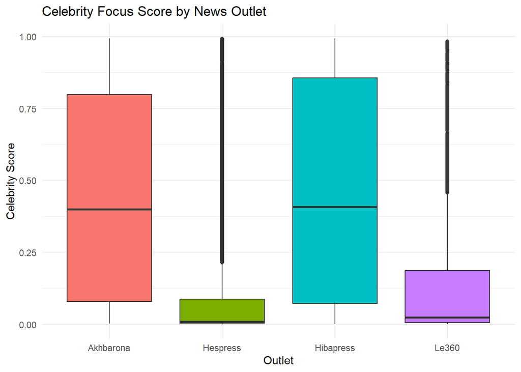

```r
# Boxplot of celebrity score by outlet
ggplot(culture_df %>% filter(!is.na(celebrity_score)),
       aes(x = source, y = celebrity_score, fill = source)) +
  geom_boxplot() +
  labs(
    title = "Celebrity Focus Score by News Outlet",
    x = "Outlet",
    y = "Celebrity Score",
    fill = "Outlet"
  ) +
  theme_minimal() +
  theme(legend.position = "none")
```

**Figure 5.** Boxplot of celebrity focus scores by news outlet. The horizontal line within each box represents the median, the box spans the interquartile range, and the whiskers extend to the most extreme non-outlier values.

The boxplot reveals stark differences in celebrity focus across outlets. Akhbarona and Hibapress show substantially higher median celebrity scores and wider distributions, indicating that celebrity content is central to their coverage and varies considerably across articles. Hespress and Le360 by contrast cluster near zero, with tight distributions and low medians, confirming that celebrity content is marginal in their output.

**Other text features we’re creating**

```r
# Add quick text features to culture_df
culture_df <- culture_df %>%
  mutate(

    # Average word length in characters — celebrity writing tends to be simpler
    avg_word_length = nchar(gsub("[^a-zA-Z\u0600-\u06FF]", "", Body)) / article_length,

    # Quote density — how often reporting verbs appear per word
    quote_density = str_count(Body, "قال|قالت|أكد|أكدت|صرح|أوضح") / article_length
  )

#Has number in title — celebrity articles often have listicle-style titles ("5 things about...")
culture_df <- culture_df %>%
  mutate(title_has_number = as.integer(str_detect(Title, "[0-9]")))
```

For the next set of variables created, I ask the question of what makes an article celebrity focused theoritically.

- It’s about a specific person (not an institution or event)
- It has an emotional or dramatic angle (scandal, death, romance)
- It’s reactive (responding to something a celebrity did or said)

So meaningful dummy variables could be the following

```r
#Article mentions death/obituary — could capture the poetry/obituary topic bleeding into celebrity
culture_df <- culture_df %>%
  mutate(mentions_death = as.integer(str_detect(Body, "وفاة|توفي|رحيل|فقدنا")))


#Article mentions a prize or award — captures cinema awards topic
culture_df <- culture_df %>%
  mutate(mentions_award = as.integer(str_detect(Body, "جائزة|تكريم|فاز|حصل")))

#Article mentions social media platforms — directly relevant to celebrity social media topic
culture_df <- culture_df %>%
  mutate(mentions_socialmedia = as.integer(str_detect(Body, "يوتيوب|انستغرام|تيكتوك|فيسبوك|تويتر")))
```

As part of this analysis, I attempted to enrich the predictor set by extracting named entity information from the article texts using the CAMeL Tools Arabic NER model (ner-arabert), a BERT-based named entity recognition system trained on Modern Standard Arabic.

For each article, the model was applied to the first 100 words of the body text — corresponding roughly to the opening paragraph. This truncation was a deliberate methodological choice justified by two considerations: first, Arabic digital news follows the inverted pyramid structure, meaning the most newsworthy information including the names of individuals involved appears in the opening lines; second, applying the full NER pipeline to 15,966 complete articles was computationally hard within the timeframe of this project.

From the entity tags produced, two variables were constructed: person_count, measuring the raw number of person-name tokens identified per article, and person_density, which normalizes that count by article length to account for the fact that longer articles will naturally contain more names. The theoretical motivation is straightforward — celebrity-focused articles are by definition about specific individuals and should therefore exhibit systematically higher person name density than articles covering institutional events, cultural policy, or literary topics

```r
# Load NER results from Python
ner_results <- read_csv("C:/Users/hp/Documents/DAT505/DAT505-RR2/ner_results.csv",
                        show_col_types = FALSE)

# Quick check — make sure it looks right
head(ner_results)
```

```
# A tibble: 6 × 3
  doc_id person_count person_density
   <dbl>        <dbl>          <dbl>
1      1            0        0
2      2            4        0.00517
3      3            2        0.00414
4      4            6        0.0173
5      5            6        0.1
6      6            8        0.0223
```

```r
nrow(ner_results)
```

```
[1] 15966
```

```r
# Join to culture_df by doc_id
culture_df <- culture_df %>%
  left_join(ner_results, by = "doc_id")

# Quick sanity check — distribution of person counts
summary(culture_df$person_count)
```

```
   Min. 1st Qu.  Median    Mean 3rd Qu.    Max.
  0.000   3.000   5.000   6.399   9.000  53.000
```

```r
summary(culture_df$person_density)
```

```
    Min.  1st Qu.   Median     Mean  3rd Qu.     Max.
0.000000 0.008818 0.023622 0.039617 0.054403 1.000000
```

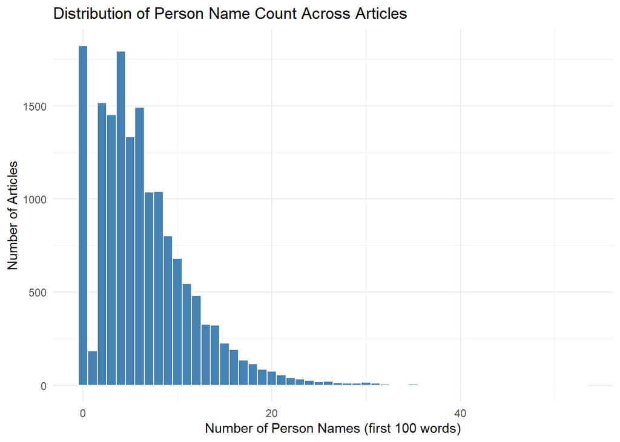

```r
# Histogram of person count distribution
ggplot(culture_df, aes(x = person_count)) +
  geom_histogram(binwidth = 1, fill = "steelblue", color = "white") +
  labs(
    title = "Distribution of Person Name Count Across Articles",
    x = "Number of Person Names (first 100 words)",
    y = "Number of Articles"
  ) +
  theme_minimal()
```

**Figure 6.** Distribution of person name counts across articles, based on named entity recognition applied to the first 100 words of each article.

Figure 6 shows a right-skewed distribution. Most articles mention between 1 and 10 person names in their opening 100 words, with the frequency dropping sharply beyond that. A small number of articles contain upwards of 20 named individuals.

With all predictors constructed, a model dataframe was assembled containing only the outcome variable and the relevant predictors.

The reason we need `model_df` separately is that `culture_df` still has lots of columns we don’t want in the regression (Title, Body, doc_id, total_words, the other topic proportions etc.). `model_df` is a clean, lean version with only the outcome + predictors.

Since named entity recognition was applied to a fixed window of 100 words per article rather than the full text, person_count — the raw number of person-name tokens identified — is retained as the more appropriate measure, as normalizing by article length would be meaningless when the input length is already held constant.

```r
  # Keep only the variables we need: outcome + predictors

model_df <- culture_df %>%
  select(celebrity_score, source, article_length, title_length,
         vocab_rich, foreign_prop, avg_word_length, quote_density, title_has_number, mentions_death, mentions_award, mentions_socialmedia, person_count ) %>%
  na.omit() #i checked for nas before i have one row that's empty because there is no text in the body so that's what's getting omitted by this line
```

### **CHECKING OUTLIERS**

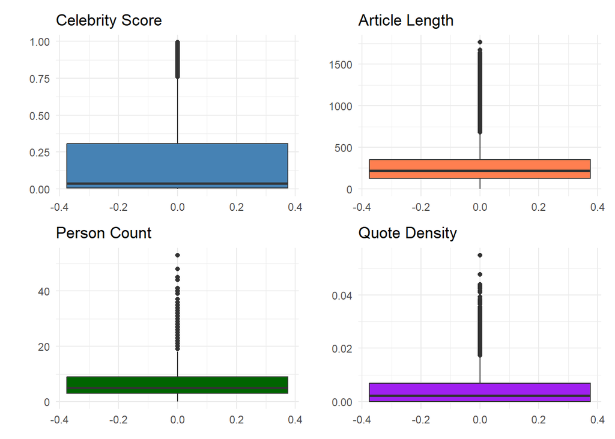

```r
# Boxplots for outcome and main predictors to identify outliers
p1 <- ggplot(model_df, aes(y = celebrity_score)) +
  geom_boxplot(fill = "steelblue") +
  labs(title = "Celebrity Score", y = "") +
  theme_minimal()

p2 <- ggplot(model_df, aes(y = article_length)) +
  geom_boxplot(fill = "coral") +
  labs(title = "Article Length", y = "") +
  theme_minimal()

p3 <- ggplot(model_df, aes(y = person_count)) +
  geom_boxplot(fill = "darkgreen") +
  labs(title = "Person Count", y = "") +
  theme_minimal()

p4 <- ggplot(model_df, aes(y = quote_density)) +
  geom_boxplot(fill = "purple") +
  labs(title = "Quote Density", y = "") +
  theme_minimal()

library(patchwork)
p1 + p2 + p3 + p4
```

**Figure 7.** Boxplots of key variables used in the predictive model, used to identify outliers.

Boxplot inspection reveals the presence of outliers across all four variables examined. Celebrity score shows a cluster of articles with near-maximum scores, reflecting pieces entirely dominated by celebrity content. Article length, person count, and quote density each contain a small number of extreme values — unusually long articles, pieces mentioning a large number of individuals, and heavily quoted texts respectively. These outliers are retained in the main analysis on the grounds that they represent genuine variation in the corpus rather than data entry errors. Their influence on model results will be assessed in the sensitivity check section.

### SENSITIVITY ANALYSIS

Specification curve analysis using the specr package could not be implemented due to version compatibility issues. Given the nature of this analysis — where the key analytical decisions concern variable inclusion and outlier treatment rather than model family or functional form — a manual comparison across four targeted specifications is sufficient.

```r
# Refit main model on full dataset for sensitivity analysis
# Note: main_model in the predictive section is fitted on train set only
# Here we refit on full model_df for fair cross-specification comparison
main_model_full <- lm(celebrity_score ~ ., data = model_df)

# Create outlier-free dataset
model_df_no_outliers <- model_df %>%
  filter(
    abs(scale(celebrity_score)) < 3,
    abs(scale(article_length)) < 3,
    abs(scale(person_count)) < 3,
    abs(scale(quote_density)) < 3
  )

# Fit alternative specifications
model_no_outliers <- lm(celebrity_score ~ ., data = model_df_no_outliers)
model_no_ner      <- lm(celebrity_score ~ . - person_count, data = model_df)
model_outlet_only <- lm(celebrity_score ~ source, data = model_df)

# Compare performance across specifications
sensitivity_results <- data.frame(
  Specification = c("Main model (all predictors)",
                    "Without outliers",
                    "Without NER variable",
                    "Outlet identity only"),
  N = c(nrow(model_df), nrow(model_df_no_outliers),
        nrow(model_df), nrow(model_df)),
  R2 = round(c(summary(main_model_full)$r.squared,
               summary(model_no_outliers)$r.squared,
               summary(model_no_ner)$r.squared,
               summary(model_outlet_only)$r.squared), 4),
  Adj_R2 = round(c(summary(main_model_full)$adj.r.squared,
                   summary(model_no_outliers)$adj.r.squared,
                   summary(model_no_ner)$adj.r.squared,
                   summary(model_outlet_only)$adj.r.squared), 4),
  RMSE = round(c(sqrt(mean(main_model_full$residuals^2)),
                 sqrt(mean(model_no_outliers$residuals^2)),
                 sqrt(mean(model_no_ner$residuals^2)),
                 sqrt(mean(model_outlet_only$residuals^2))), 4)
)

kable(sensitivity_results,
      col.names = c("Specification", "N", "R²", "Adjusted R²", "RMSE"),
      caption = "Table 4. Sensitivity Analysis: Model Performance Across Specifications") %>%
  kable_styling(full_width = FALSE, font_size = 12)
```

Table 4. Sensitivity Analysis: Model Performance Across Specifications

| Specification | N | R² | Adjusted R² | RMSE |
| --- | --- | --- | --- | --- |
| Main model (all predictors) | 15965 | 0.3864 | 0.3859 | 0.2363 |
| Without outliers | 15119 | 0.3788 | 0.3782 | 0.2366 |
| Without NER variable | 15965 | 0.3862 | 0.3857 | 0.2363 |
| Outlet identity only | 15965 | 0.2574 | 0.2573 | 0.2599 |

### ASSUMPTION CHECKS

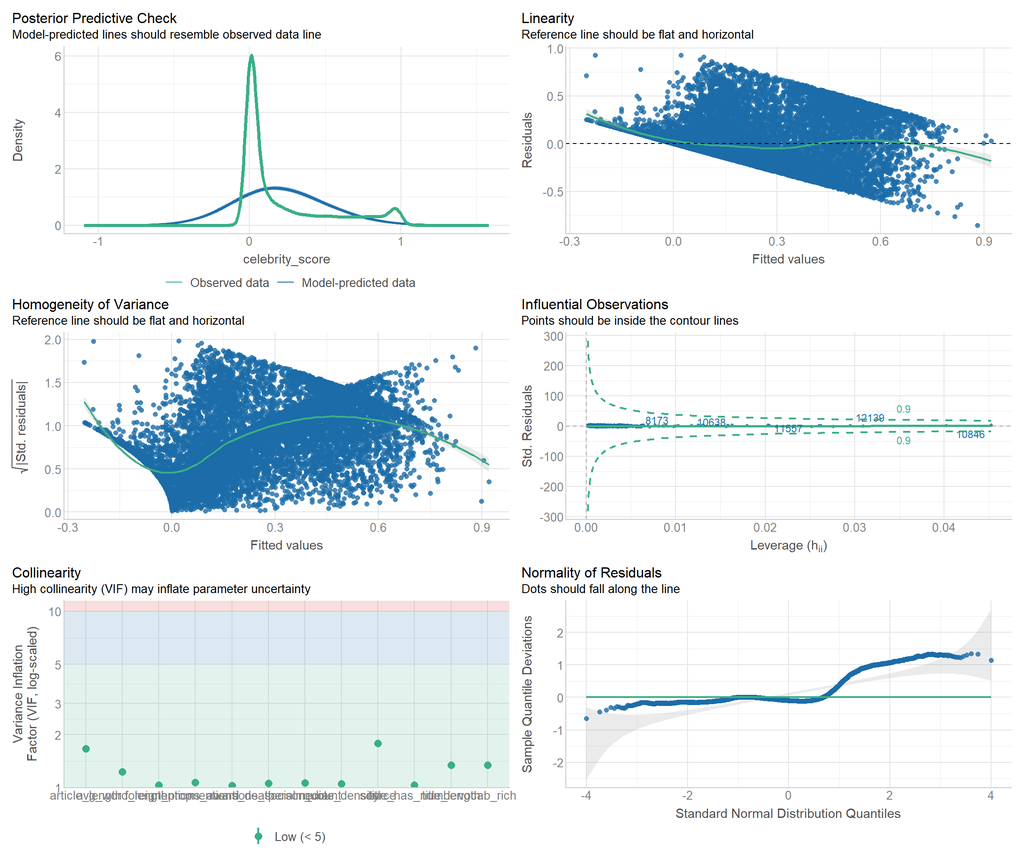

```r
library(performance)
library(see)

check_model(main_model_full)
```

**Figure 8.** Assumption checks for the main linear regression model, produced using the check_model() function from the performance package. Panels show from top left to bottom right: posterior predictive check, linearity, homogeneity of variance, influential observations, collinearity (VIF), and normality of residuals.

The posterior predictive check shows a mismatch between observed and model-predicted distributions — the model predicts a smoother, more symmetric distribution while the actual celebrity scores are heavily concentrated near zero with a secondary spike at 1. This is expected given the bounded, bimodal nature of topic proportions.

The linearity check shows the reference line is not perfectly flat, indicating mild non-linearity. The model captures the general trend but imperfectly at the extremes.

The homogeneity of variance check reveals heteroskedasticity — variance in residuals increases at higher fitted values, meaning the model is less precise when predicting high celebrity scores.

The collinearity check shows all VIF values well below 5, confirming no multicollinearity among predictors.

The normality of residuals shows clear deviation from normality at the tails. With nearly 16,000 observations however, coefficient estimates remain reliable by the central limit theorem regardless of residual non-normality.

## SECTION 2: Predictive Modelling of Celebrity Focus

### Baseline Model Performance: Train/Test Split

The dataset is split into 80% for training and 20% for testing. A linear regression is fitted on the training set only, then used to predict celebrity scores on the test set (data the model has never seen). This tells us how well the model generalises beyond the data it was trained on.

```r
# TRAIN / TEST SPLIT

set.seed(123) # for reproducibility

# Randomly select 80% of row indices for training
train_idx <- sample(1:nrow(model_df), size = 0.8 * nrow(model_df))

# Split into train and test sets
train <- model_df[train_idx, ]
test  <- model_df[-train_idx, ]
```

```r
# FIT MAIN MODEL ON TRAIN SET

# Linear regression predicting celebrity_score from all predictors
main_model <- lm(celebrity_score ~ ., data = train)

# Predict on the test set
predictions <- predict(main_model, newdata = test)
```

```r
# EVALUATE PERFORMANCE

# RMSE: average prediction error (lower = better)
rmse <- sqrt(mean((test$celebrity_score - predictions)^2))

# R-squared: proportion of variance explained (higher = better)
r2 <- cor(test$celebrity_score, predictions)^2

# MAE: mean absolute error — average absolute difference between predicted and actual
mae <- mean(abs(test$celebrity_score - predictions))

# Print all metrics
cat("RMSE:", round(rmse, 4), "\n")
```

```
RMSE: 0.2382
```

```r
cat("R²:  ", round(r2, 4), "\n")
```

```
R²:   0.3778
```

```r
cat("MAE: ", round(mae, 4), "\n")
```

```
MAE:  0.1766
```

```r
# Full model summary on train set — shows coefficients and significance
summary(main_model)
```

```
Call:
lm(formula = celebrity_score ~ ., data = train)

Residuals:
     Min       1Q   Median       3Q      Max
-0.85636 -0.13732 -0.04562  0.09312  0.92821

Coefficients:
                       Estimate Std. Error t value Pr(>|t|)
(Intercept)           9.790e-01  4.927e-02  19.869  < 2e-16 ***
sourceHespress       -2.211e-01  7.673e-03 -28.812  < 2e-16 ***
sourceHibapress       1.448e-02  8.159e-03   1.775   0.0760 .
sourceLe360          -2.303e-01  8.107e-03 -28.410  < 2e-16 ***
article_length       -2.195e-04  1.203e-05 -18.239  < 2e-16 ***
title_length          6.050e-03  1.079e-03   5.607 2.11e-08 ***
vocab_rich            2.544e-01  3.348e-02   7.600 3.17e-14 ***
foreign_prop          9.193e-01  1.226e-01   7.498 6.91e-14 ***
avg_word_length      -1.692e-01  6.909e-03 -24.495  < 2e-16 ***
quote_density         6.815e+00  3.777e-01  18.042  < 2e-16 ***
title_has_number     -6.052e-02  8.219e-03  -7.363 1.91e-13 ***
mentions_death        2.028e-03  6.347e-03   0.319   0.7494
mentions_award       -4.495e-02  5.009e-03  -8.975  < 2e-16 ***
mentions_socialmedia  1.384e-01  7.163e-03  19.326  < 2e-16 ***
person_count         -8.528e-04  4.158e-04  -2.051   0.0403 *
---
Signif. codes:  0 '***' 0.001 '**' 0.01 '*' 0.05 '.' 0.1 ' ' 1

Residual standard error: 0.2359 on 12757 degrees of freedom
Multiple R-squared:  0.3885,    Adjusted R-squared:  0.3879
F-statistic:   579 on 14 and 12757 DF,  p-value: < 2.2e-16
```

*Side note: The negative coefficient for person_count is counterintuitive given the theoretical expectation that celebrity articles mention more individuals. One possible explanation is that the NER model, applied only to the first 100 words, may have picked up on person names in non-celebrity contexts — such as author names in literary articles or politician names in cultural policy pieces — introducing noise into the variable. This limitation will be addressed in future work by applying NER to the full article text.*

### CROSS VALIDATION

**CV with 10 FOLD**

A single train/test split depends on which particular 80% of the data ends up in training. This means a different random split could give slightly different results. 10-fold cross-validation addresses this by splitting the full dataset into 10 equal chunks, training on 9 and testing on 1, rotating through all 10 combinations and averaging the results. This gives a more reliable and stable estimate of predictive performance.

```r
library(caret)

# Define 10-fold cross-validation rules
train_control_cv <- trainControl(
  method = "cv",
  number = 10
)

# Launch model training with 10-fold CV
cv_model <- train(
  celebrity_score ~ .,
  data      = model_df,
  method    = "lm",
  metric    = "RMSE",
  trControl = train_control_cv
)

print(cv_model)
```

```
Linear Regression

15965 samples
   12 predictor

No pre-processing
Resampling: Cross-Validated (10 fold)
Summary of sample sizes: 14369, 14368, 14369, 14368, 14368, 14369, ...
Resampling results:

  RMSE       Rsquared   MAE
  0.2365042  0.3852647  0.1770711

Tuning parameter 'intercept' was held constant at a value of TRUE
```

10-fold cross-validation was chosen given the large sample size (n = 15,965), which ensures each fold contains sufficient observations for stable estimation. Across the 10 folds, the model achieves an average RMSE of 0.237, R² of 0.385, and MAE of 0.177.

- RMSE of 0.237 means that on average the model’s predictions deviate from the true celebrity score by about 0.24 units.
- MAE of 0.177 tells a similar story but is less sensitive to large errors: the typical prediction is off by roughly 0.18 units.
- R² of 0.385 means the model accounts for about 39% of the variance in celebrity focus across articles.

### **CV with BOOTSTRAP**

Bootstrap resampling repeatedly draws random samples with replacement from the full dataset, meaning some articles appear multiple times in a sample and others not at all. This is done 10 times, each time training on the bootstrap sample and testing on the original data. It’s a different way of estimating model stability that doesn’t require splitting the data into fixed folds.

```r
# Define bootstrap rules
train_control_boot <- trainControl(
  method = "boot",
  number = 10
)

# Launch model training with bootstrap
cv_model_boot <- train(
  celebrity_score ~ .,
  data      = model_df,
  method    = "lm",
  metric    = "RMSE",
  trControl = train_control_boot
)

print(cv_model_boot)
```

```
Linear Regression

15965 samples
   12 predictor

No pre-processing
Resampling: Bootstrapped (10 reps)
Summary of sample sizes: 15965, 15965, 15965, 15965, 15965, 15965, ...
Resampling results:

  RMSE       Rsquared   MAE
  0.2369975  0.3835146  0.1773908

Tuning parameter 'intercept' was held constant at a value of TRUE
```

The bootstrap results are nearly identical to the 10-fold CV estimates: RMSE of 0.237, R² of 0.384, and MAE of 0.177. The fact that two fundamentally different resampling strategies — one splitting the data into fixed folds, the other drawing random samples with replacement — converge on the same performance figures is strong evidence that the model’s predictive performance is genuine and stable. The consistency across train/test split, 10-fold CV, and bootstrap resampling — all pointing to roughly RMSE ≈ 0.24 and R² ≈ 0.38 — gives confidence that these estimates are not an artifact of any particular methodological choice.

### LASSO REGRESSION FOR PREDICTION

Lasso regression works like linear regression but adds a penalty for complexity. It shrinks coefficients of less useful variables towards zero and can drop them entirely. This forces the model to identify the most predictive subset of variables rather than just using everything. The optimal penalty strength (lambda) is chosen via 10-fold CV, selecting the value that minimises prediction error.

```r
library(glmnet)

# Define CV rules for lasso
tc_lasso <- trainControl(
  method = "cv",
  number = 10
)

# Train lasso model — alpha=1 means lasso, lambda range searched via CV
model_lasso <- train(
  celebrity_score ~ .,
  data     = model_df,
  method   = "glmnet",
  tuneGrid = expand.grid(alpha = 1, lambda = seq(0, 0.01, 0.0001)),
  metric   = "RMSE",
  trControl = tc_lasso
)

# Best lambda chosen by CV
model_lasso$bestTune
```

```
  alpha lambda
4     1  3e-04
```

```r
# Results at best lambda
model_lasso$results[which(model_lasso$results$lambda == model_lasso$finalModel$lambdaOpt), ]
```

```
  alpha lambda      RMSE Rsquared       MAE      RMSESD RsquaredSD       MAESD
4     1  3e-04 0.2364411 0.385788 0.1770616 0.003037659 0.01666517 0.002108308
```

```r
# Which variables survived lasso?
coef(model_lasso$finalModel, model_lasso$finalModel$lambdaOpt)
```

```
15 x 1 sparse Matrix of class "dgCMatrix"
                           s=3e-04
(Intercept)           0.9860251727
sourceHespress       -0.2235683652
sourceHibapress       0.0080797455
sourceLe360          -0.2316109120
article_length       -0.0002157367
title_length          0.0057246957
vocab_rich            0.2515519322
foreign_prop          0.8567183934
avg_word_length      -0.1692053067
quote_density         6.8312191188
title_has_number     -0.0638624507
mentions_death        0.0019402226
mentions_award       -0.0454840454
mentions_socialmedia  0.1377408428
person_count         -0.0007153438
```

The optimal lambda selected by cross-validation is 0.0003 — a very small penalty — indicating that lasso found little reason to eliminate any predictor. All 14 variables survived with non-zero coefficients, suggesting that each carries at least marginal predictive signal. This outcome reflects both the genuine informativeness of the predictor set and its relatively modest size. Lasso’s variable selection properties are most pronounced when the number of candidate predictors substantially exceeds the number of truly informative ones, a condition not met here.

At this optimal lambda, the model achieves RMSE of 0.236, R² of 0.386, and MAE of 0.177 — virtually identical to both the train/test split and cross-validation estimates. The stability of these figures across three different evaluation approaches is the central finding of this section: the model consistently explains around 38-39% of variance in celebrity focus regardless of how performance is assessed.

In terms of which variables matter most, the lasso coefficients mirror the linear regression findings. Outlet identity remains dominant: Hespress and Le360 show the largest negative coefficients (β = -0.22 and β = -0.23 respectively), while Hibapress barely differs from Akhbarona (β = 0.008), confirming that Akhbarona and Hibapress are the two celebrity-oriented outlets. Among text features, quote density remains by far the strongest predictor (β = 6.83) — articles quoting individuals more frequently are substantially more celebrity-focused. Mentions of social media platforms is strongly positive (β = 0.14), directly reflecting the social media orientation of celebrity content. Foreign script proportion shows a positive association (β = 0.86), average word length a negative one (β = -0.17), and vocabulary richness a modest positive effect (β = 0.25). Mentions of awards is negative (β = -0.05), consistent with award coverage skewing toward serious cinema. Mentions of death survives with a negligible coefficient (β = 0.002), carrying no practical importance despite not being dropped. Person count shows a small negative effect (β = -0.001), a counterintuitive finding discussed in the previous section.

Overall, the lasso results confirm that the most predictive model available with this predictor set is essentially the full model — no variable was redundant enough to eliminate. The consistent R² of approximately 38% across all three evaluation methods represents a meaningful level of predictive performance for text-derived data, and suggests that the combination of outlet identity, linguistic features, and content markers captures genuine signal about what drives celebrity focus in Moroccan cultural news.

# CONCLUSION

This report has two main limitations that are worth addressing directly.

On the topic modelling side, the quality of the output is only as good as the preprocessing that precedes it. Arabic presents specific challenges that standard R packages are not built for — stopword lists designed for Western languages miss a substantial portion of Arabic functional words, and no reliable stemmer exists in R for Arabic. The custom stopword list developed here required significant manual iteration, and a basic prefix-stripping approach was used in place of proper morphological stemming. As a result, the same word likely appears in multiple surface forms across topics, introducing noise and reducing thematic coherence. A proper Arabic NLP pipeline — with root-based stemming and a comprehensive domain-specific stopword list — would produce sharper, more interpretable topics. Despite these limitations, the ten topics identified are semantically coherent and the outlet-level differences are statistically robust across both regression and bootstrap analyses.

On the predictive modelling side, the core challenge is that creating meaningful predictors from raw text is genuinely difficult. Most standard feature engineering approaches assume English or at minimum a language with mature NLP tooling. The variables constructed here — structural features like article length and vocabulary richness, binary content markers, and NER-based person counts — represent a reasonable first attempt but are ultimately surface-level proxies for what actually drives celebrity focus. The NER pipeline itself was constrained to the first 100 words per article due to computational limitations, which likely introduced noise into the person_count variable. The lasso regression retained all predictors, suggesting the predictor set is not large enough to trigger meaningful variable selection — which would require substantially more variables, ideally word-level dummies at scale, to address properly. That said, the final model achieves an R² of approximately 38% consistently across train/test, 10-fold CV, and bootstrap evaluation — a reasonable level of predictive performance for text-derived data — and the stability of results across all three evaluation methods gives confidence that the findings are not an artifact of any particular methodological choice.